# Collective Agreements

Rubén Pérez Sanz

2023-06-27

# Descriptives of Collective Agreements in Spain

The main purpose of this document is to have an idea of how collective agreements work in Spain.

## Setting

### Load

The libraries that I will need:

```r
library(dplyr)
library(ggplot2)
library(statsr)
library(readxl)
library(expss)
library(stringr)
library(zoo)
```

### Define the paths

```r
dell <- 0
if (dell == 1) {
    computer <- "C:/Users/jj22684/"
} else {
    computer <- "C:/Users/lenovo/"
}

setwd(paste0(computer,"Dropbox/WORK/data/REGCON/Codes/FIRM/read"))
Main_path   <- paste(computer, "Dropbox/WORK/data/REGCON", sep = "")
raw_path      <- paste(computer, "Dropbox/WORK/data/REGCON/RAW files", sep = "")
```

### Load the database

```r
load(paste(Main_path, "/Files/FIRM/cleant/regconfirm_cleant.R", sep = ""))
```

## Filter

### Informed fields

In the database, many obs in the the fields publi_date_temp and start_nego_temp are missing, when they are missed usually there rest of the variables are not informed.

The fact that there is no information does not mean that there wasn’t a collective agreement.

```r
REGCON_FIRM <- REGCON_FIRM %>%
    mutate(informed = (!is.na(dtpubli) == 'TRUE')&(!is.na(dtstrnego) == 'TRUE'))
#val_lab(REGCON_FIRM$informed) = make_labels("1 Yes 0 No")
REGCON_FIRM %>% group_by(informed)%>%
    summarise(val = mean(as.numeric(informed)), n = n(), freq = n()/as.numeric(count(REGCON_FIRM)))
```

```
## # A tibble: 2 × 4
##   informed   val     n  freq
##   <lgl>    <dbl> <int> <dbl>
## 1 FALSE        0  8937 0.428
## 2 TRUE         1 11947 0.572
```

```r
#REGCON_FIRM <- REGCON_FIRM %>%
    #filter(!is.na(publi_date_temp) == 'TRUE', !is.na(start_nego_temp) == 'TRUE')
```

### Nature

Most agreements are plain CA at firm level, followed by mediation agreements and limited efficacy.

In the second graph it is clear that many observations are not informed because the are:

- Mediation agreements: they don’t need to fill the information
- Limited efficacy: I need to look further in this

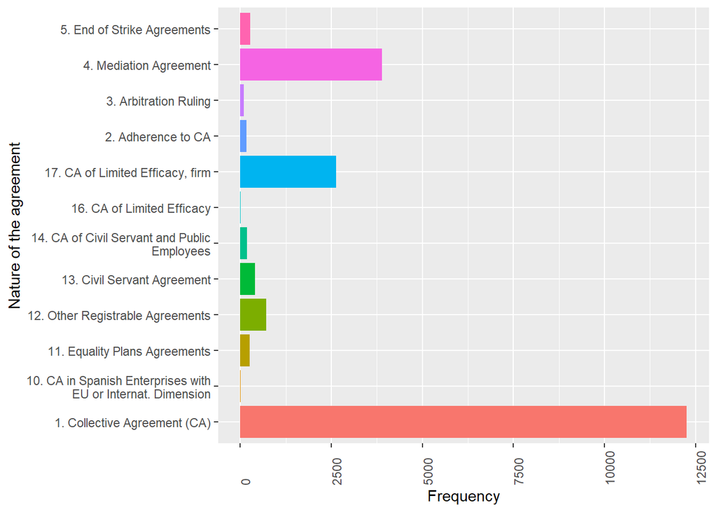

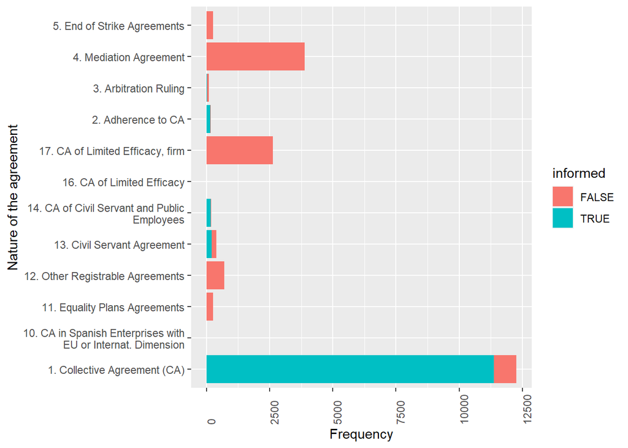

### Procedure type

The graph below shows how many CAs have been negotiated, depending on:

- New agreement: the firm didn’t have a CA and now it has
- New text: the firm had a CA in place, and it has been renegotiated

Looking at the first graphs, many agreements are brand new agreements, which are mostly not informed/missed.

In the third graph, we see that it is actually the case.

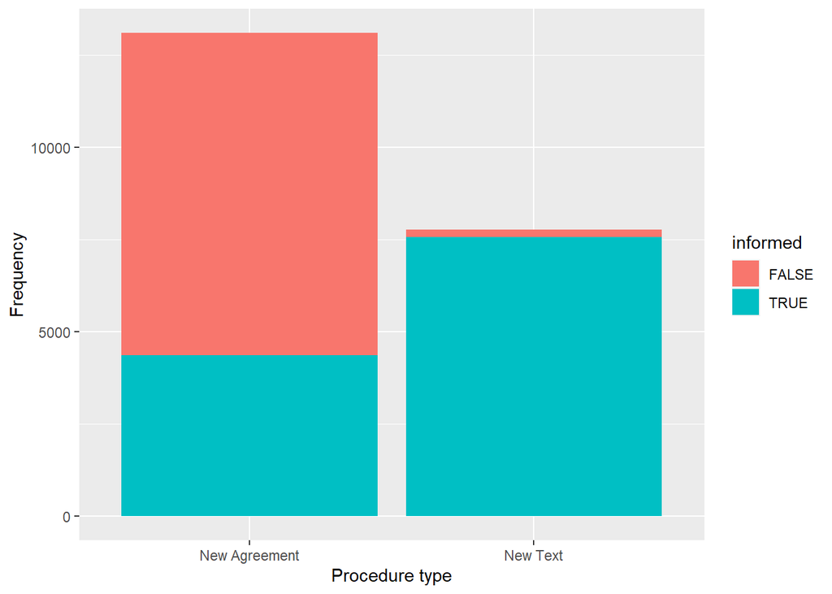

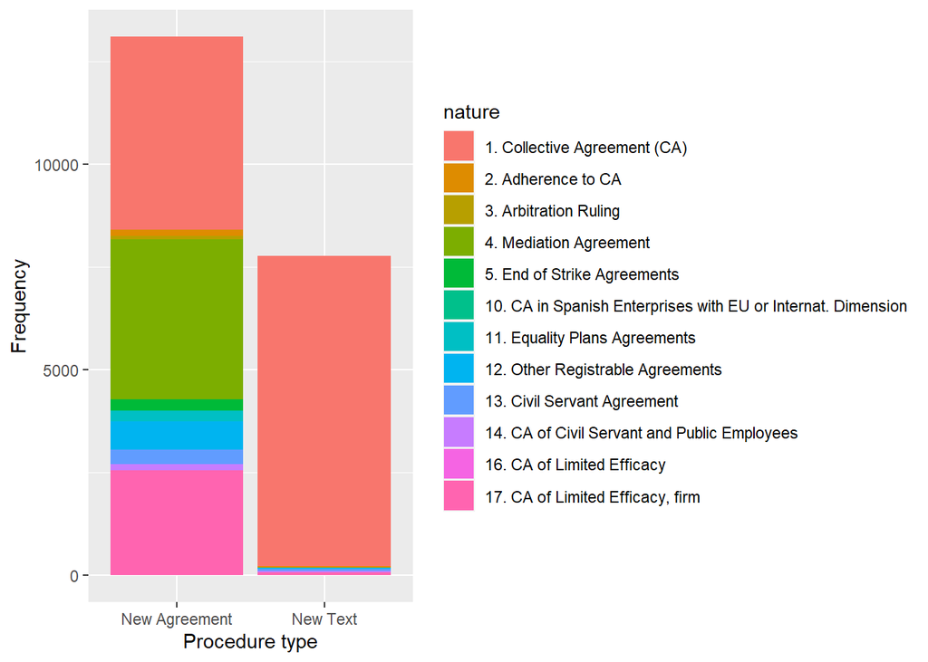

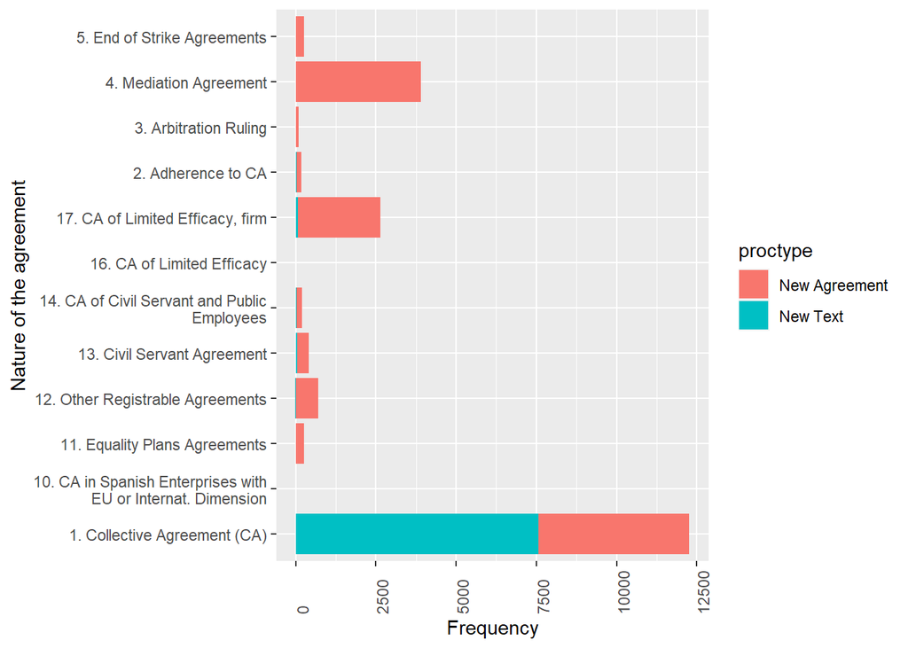

The nature of agreements could be grouped in 4 categories:

- CA:collective agreements and adherence to CA
- MA: mediating agreements, end strike agree.,and arbitration agree.,
- Limited: CA of limited efficacy, and CA of limited efficacy firm,
- And the rest.

Most of the MA, limited and the rest of agreements are ‘new aggreements’. In the case of MA makes sense since they are agreements to solve interpretational disputes about CA at a firm level.

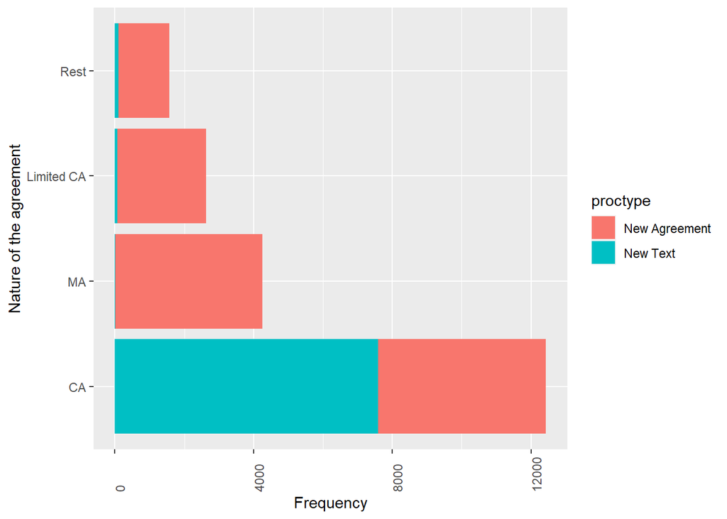

In the next graph we see that those new aggreements coincide with those that are not informed, which usually happen in agreements that are not CA at a firm level, and I will drop them from the analysis for now.

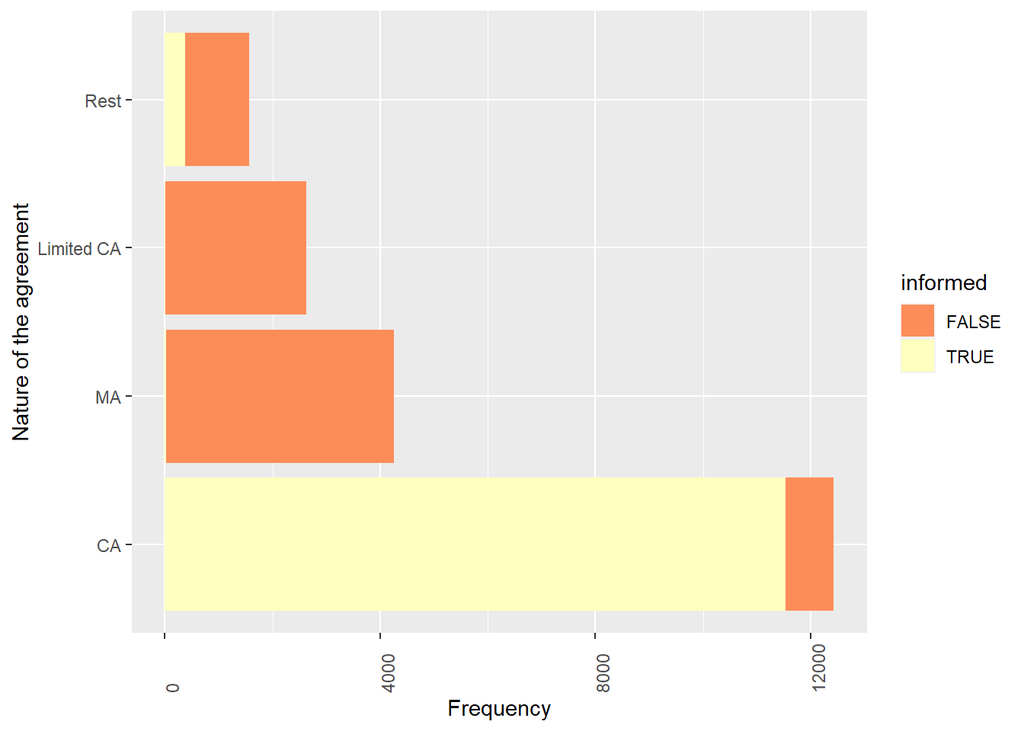

```
## # A tibble: 4 × 2
##   nature2        n
##   <fct>      <int>
## 1 CA         12426
## 2 MA          4260
## 3 Limited CA  2634
## 4 Rest        1564
```

## Descriptives

### State of the agreement

Those that are cancelled by a court ruling should not have validity, and I will drop them.

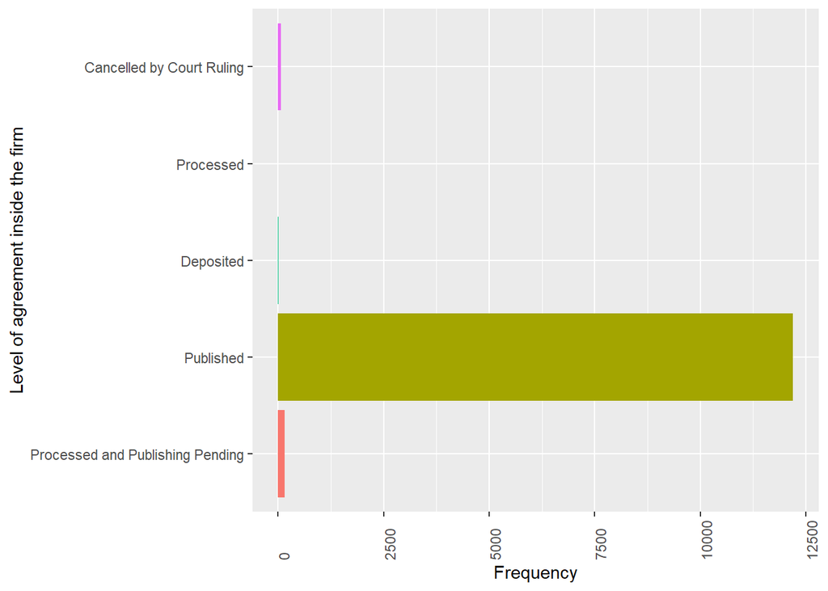

```
## # A tibble: 5 × 2
##   state                                n
##   <fct>                            <int>
## 1 Processed and Publishing Pending   150
## 2 Published                        12197
## 3 Deposited                           10
## 4 Processed                            2
## 5 Cancelled by Court Ruling           67
```

```
##
##                ProcesaPP Published Deposited Processed GuaraaARO CancelbCR
##   1.CollectiA(       149     12028        10         2         0        67
##   2.AdherenctC         1       169         0         0         0         0
```

```
##
##         ProcesaPP Published Deposited Processed GuaraaARO CancelbCR
##   FALSE       150       728        10         2         0         0
##   TRUE          0     11469         0         0         0        67
```

```
##
##         2010 2011 2012 2013 2014 2015 2016 2017 2018
##   FALSE    6   19  259  234   85   44   23   21  199
##   TRUE    15  740 1056 1689 1534 1379 1532 1754 1837
```

Finally, for those that are not informed are dropped since all the info is missing.

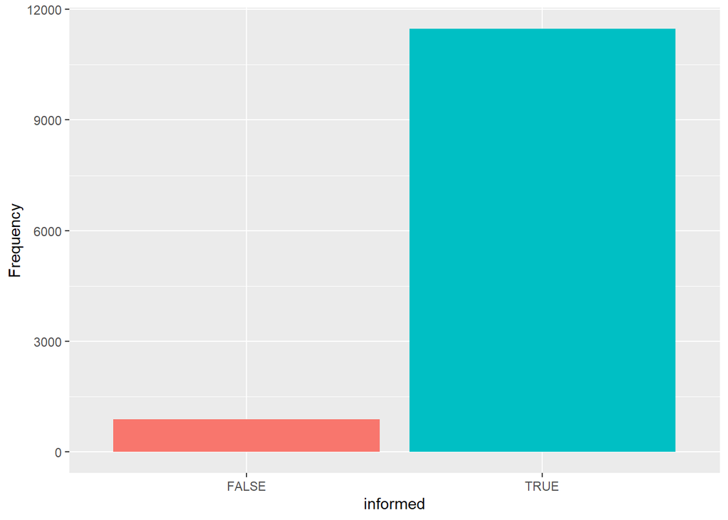

```
## # A tibble: 2 × 4
##   informed   val     n   freq
##   <lgl>    <dbl> <int>  <dbl>
## 1 FALSE        0   890 0.0720
## 2 TRUE         1 11469 0.928
```

In the end we end up with 11469 CA at a firm level.